# peruse 0.2.0

Jacob Goldsmith

2020-12-21

I’m excited to announce that [peruse 0.2.0](https://jacgoldsm.github.io/peruse/) is now available on CRAN!

Install peruse from CRAN with:

```r
install.packages("peruse")
```

Alternatively, if you need the development version from GitHub install it with:

```r
devtools::install_github("jacgoldsm/peruse")
```

`peruse` has two main distinct capabilities, related by the idea that they ‘peruse’ a sequence:

- Set or list comprehension, aimed at capturing sets that meet complex conditions
- `Iterator`s that make it easier to generate irregular sequences and sets that are difficult to generate with existing tools

## Iterator

In R, sequences are normally represented as atomic vectors. For example, here is how we might represent a weighted sequence of 50 1s and -1s, with 1 having 75% probability and -1 having 25% probability:

```r
sample(c(-1L, 1L), size = 50L, prob = c(0.25, 0.75), replace = T)
```

```
#>  [1] -1  1  1  1  1  1 -1  1  1  1  1  1  1  1  1  1  1  1  1  1 -1  1 -1  1  1
#> [26]  1  1  1 -1 -1  1  1  1  1  1 -1  1  1  1  1 -1  1 -1  1 -1 -1  1 -1 -1  1
```

From the perspective of the R user, all these values are generated at once. This brings up two issues:

- How do we generate a recursive sequence, that is, a sequence in which each value determines subsequent values?
- How do we generate a sequence that only generates until a condition is met if we do not know how long that will take in advance?

The `Iterator` object in `peruse` is made to solve these problem. For example, suppose we want to simulate a random walk with drift that has two end conditions: success is if/when it reaches 50, and failure is if/when it reaches -50. To be efficient, we want to stop the simulation when the sequence reaches either of the end conditions.

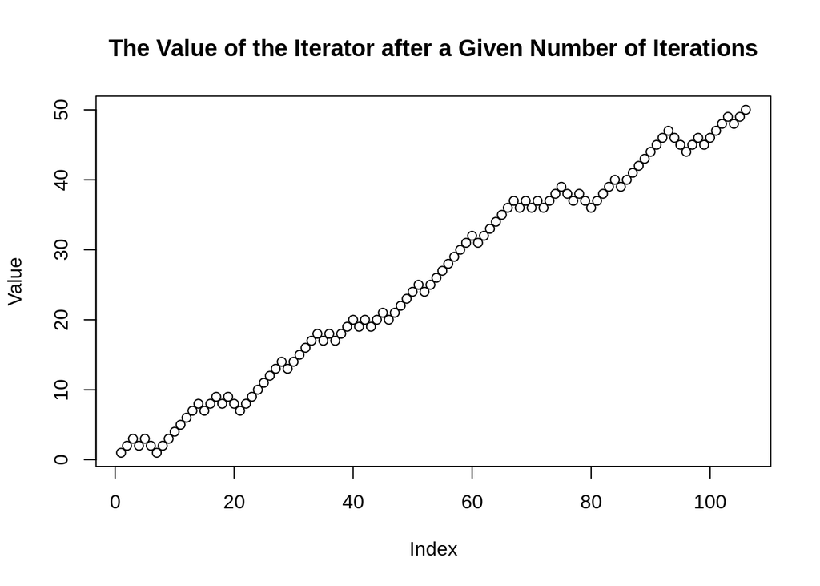

```r
set.seed(1)
expr <- 'n <- n + sample(c(-1L, 1L), size = 1L, prob = c(0.25, 0.75))'
rwd <- Iterator(result = expr,
                initial = c(n = 0),
                yield = n)


Value <- yield_while(rwd, "n != 50L & n != -50L")

plot(Value, main = "The Value of the Iterator after a Given Number of Iterations")
```

This scenario illustrates the capabilities of the `Iterator`:

- We defined the R expression for generating a new element in advance of the simulation
- We defined initial values for all of the variables involved (in this case just `n`)
- We defined a variable to return each time `yield_next` was called
- We generated the sequence recursively, modifying the value of `n` each time we computed a new one
- We made the process stop whenever `n` reached 50 or -50

## Set Building

`peruse` develops a simple API for set comprehension. R already makes it easy to develop simple sets, like getting all the even numbers from 1 to 100:

```r
(1:100)[which(1:100 %% 2 == 0)]
```

```
#>  [1]   2   4   6   8  10  12  14  16  18  20  22  24  26  28  30  32  34  36  38
#> [20]  40  42  44  46  48  50  52  54  56  58  60  62  64  66  68  70  72  74  76
#> [39]  78  80  82  84  86  88  90  92  94  96  98 100
```

Here, we use set comprehension to generate prime numbers 1-100:

```r
2:100 %>% that_for_all(range(2, .x)) %>% we_have(~.x %% .y != 0)
```

```
#>  [1]  2  3  5  7 11 13 17 19 23 29 31 37 41 43 47 53 59 61 67 71 73 79 83 89 97
```

This doesn’t, however, help us if we want to generate a certain *number* of prime numbers, regardless of what interval they are in. Of course, we could generate a vector and then subset it, but that would be inefficient! We want to only generate what we need.

We can bring together the set-builder and Iterator capabilities to do that, for example with the first 100 primes:

```r
# 10,000 is just a number that we can be pretty sure is sufficiently high
primes <- 2:10000 %>%
            that_for_all(range(2, .x)) %>%
            we_have(~.x %% .y != 0, "Iterator")


sequence <- yield_more(primes, 100)

sequence
```

```
#>   [1]   2   3   5   7  11  13  17  19  23  29  31  37  41  43  47  53  59  61
#>  [19]  67  71  73  79  83  89  97 101 103 107 109 113 127 131 137 139 149 151
#>  [37] 157 163 167 173 179 181 191 193 197 199 211 223 227 229 233 239 241 251
#>  [55] 257 263 269 271 277 281 283 293 307 311 313 317 331 337 347 349 353 359
#>  [73] 367 373 379 383 389 397 401 409 419 421 431 433 439 443 449 457 461 463
#>  [91] 467 479 487 491 499 503 509 521 523 541
```

This illustrates a few things:

- We can generate an `Iterator` from a set by including the “Iterator” argument in `we_have()`
- We can then generate a sequence that would normally be generated all at once one-by-one
- We can then only generate the numbers we want and stop once we reach the hundredth element
- We can use the helper function `yield_more()` to automate what would require a `for` loop

## Feedback welcome!

`peruse` is a new package and needs help! If you do run into a bug or think of a new feature that would work well in `peruse` please [open an issue.](https://github.com/jacgoldsm/peruse/issues)

## Acknowledgments

Big thank you to Hadley Wickham, from whose book [Advanced R](https://adv-r.hadley.nz/index.html) I learned to do the stuff I did in the package, and whose book [R Packages](https://r-pkgs.org/index.html) was invaluable in getting `peruse` published on CRAN. Also, the piped set builder workflow was made possible by the [magrittr](https://magrittr.tidyverse.org/) pipe, so thank you to the developers: Stefan Milton Bache and Hadley Wickham.